# **Panorama da inflação**

Os principais índices de inflação do Brasil, apontam em dezembro de 2002 um avanço da inflação de em média **2.85%**. Com esse resultado, no ano a inflação acumula uma variação média positiva de **17.38%**, e em 12 meses uma variação média acumulada de **17.53%**.

[output not shown]

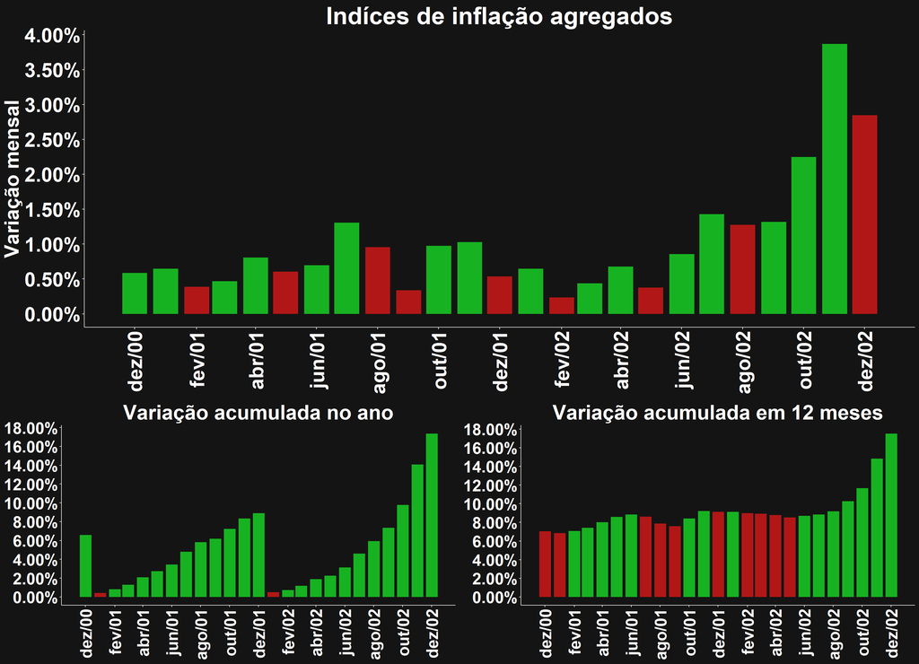

Índices selecionados para a média: IPCA, INPC e IGP-M.

# IPCA

O Indíce de Preços ao Consumidor Amplo (IPCA) variou 2.1% em dezembro, valor superior ao mesmo período do ano anterior quando apresentou uma taxa de 0.65%. Com esse resultado o indíce acumula no ano uma variação positiva de 12.53%, e em 12 meses uma variação positiva de 12.53%.

|  | 12/2001 | 11/2002 | 12/2002 |
| --- | --- | --- | --- |
| Variação mensal | 0.65% | 3.02% | 2.1% |
| Variação acumulada no ano | 7.67% | 10.22% | 12.53% |
| Variação acumulada em 12 meses | 7.67% | 10.93% | 12.53% |

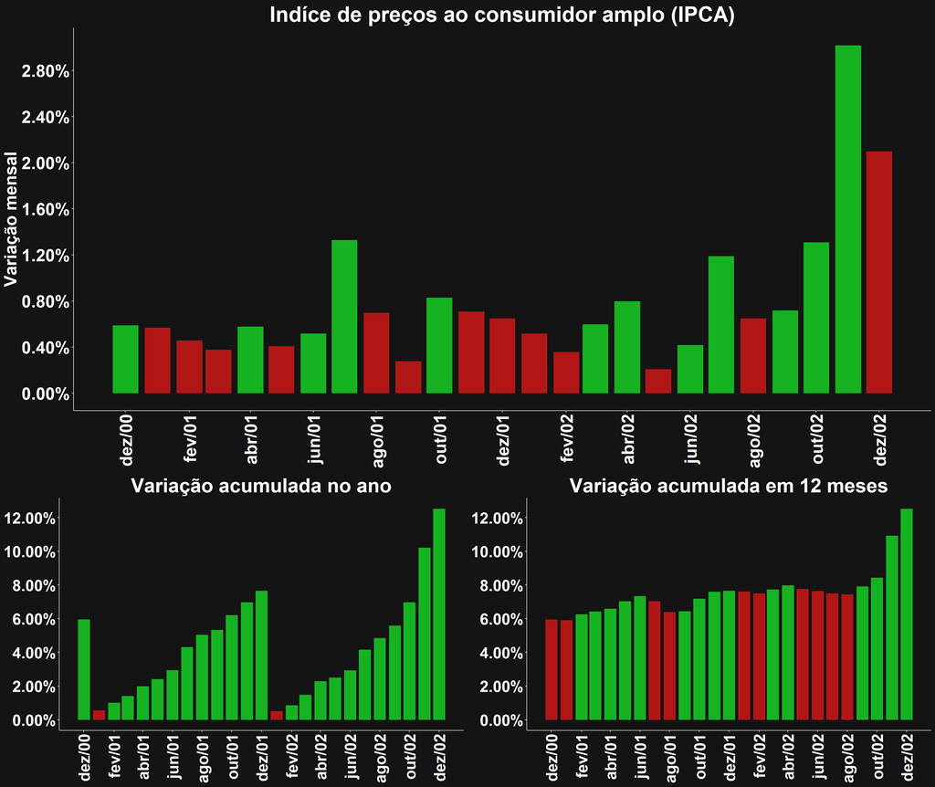

|  | Variação mensal | Variação acumulada no ano | Peso mensal |
| --- | --- | --- | --- |
| Alimentação e bebidas | 3.91% | 19.46% | 23.36% |
| Habitação | 1.42% | 12.99% | 16.22% |
| Artigos de residência | 2.12% | 12.98% | 5.73% |
| Vestuário | 0.93% | 8.82% | 5.26% |
| Transportes | 1.33% | 9.96% | 21.74% |
| Saúde e cuidados pessoais | 2.74% | 10.19% | 10.35% |
| Despesas pessoais | 2.19% | 8.37% | 9.13% |
| Educação | 0.27% | 8.43% | 4.69% |
| Comunicação | 0.03% | 11.27% | 3.52% |

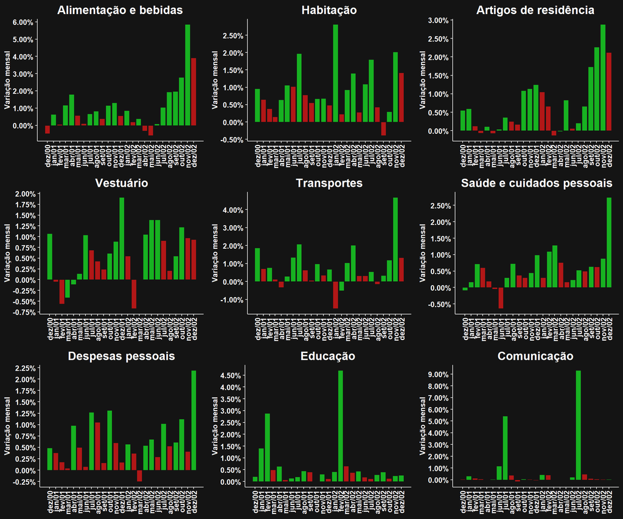

A nível de sub-itens os que mais influenciaram positivamente no resultado em relação ao seu peso foram Ônibus urbano (2.67%%) e Cigarro (10.57%%), e negativamente Compra de automóvel usado (-1.91%%) e Tomate (-24.1%%).

|  | Variação mensal | Variação acumulada no ano | Peso mensal |
| --- | --- | --- | --- |
| Frango | 8.35% | 24% | 0.9% |
| Gás de botijão | 6.77% | 48.33% | 1.68% |
| Ônibus urbano | 2.67% | 12.04% | 4.58% |
| Cigarro | 10.57% | 13.2% | 1.11% |

|  | Variação mensal | Variação acumulada no ano | Peso mensal |
| --- | --- | --- | --- |
| Compra de automóvel usado | -1.91% | 6.17% | 2.38% |
| Tomate | -24.1% | 4.85% | 0.11% |
| Limão | -24.97% | 81.46% | 0.01% |
| Manga | -5.9% | 47.34% | 0.05% |

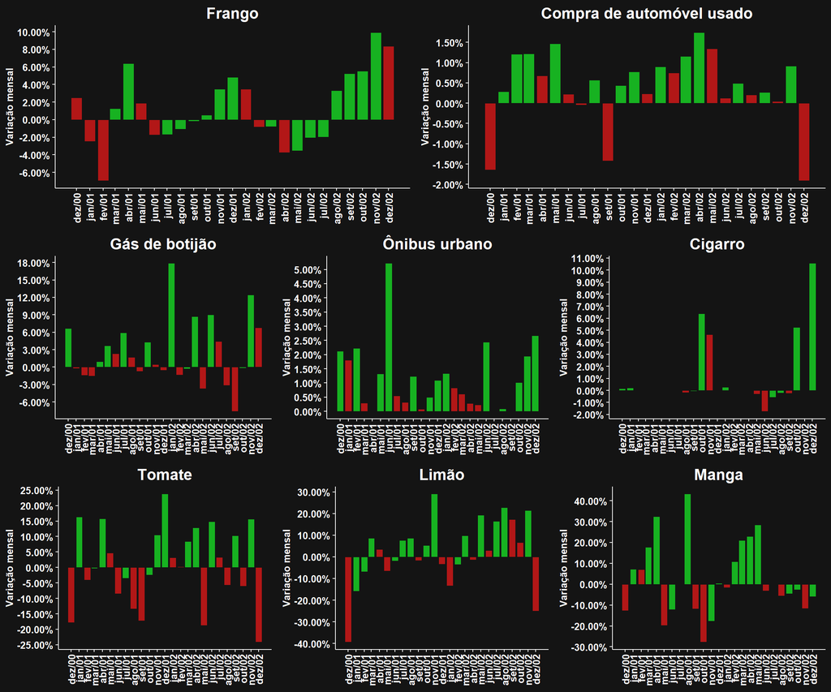

# INPC

O Indíce Nacional de Preços ao Consumidor (INPC) variou 2.7% em dezembro, valor superior ao mesmo período do ano anterior quando apresentou uma taxa de 0.74%. Com esse resultado o indíce acumula no ano uma variação positiva de 14.74%, e em 12 meses uma variação positiva de 14.74%.

|  | 12/2001 | 11/2002 | 12/2002 |
| --- | --- | --- | --- |
| Variação mensal | 0.74% | 3.39% | 2.7% |
| Variação acumulada no ano | 9.44% | 11.72% | 14.74% |
| Variação acumulada em 12 meses | 9.44% | 12.55% | 14.74% |

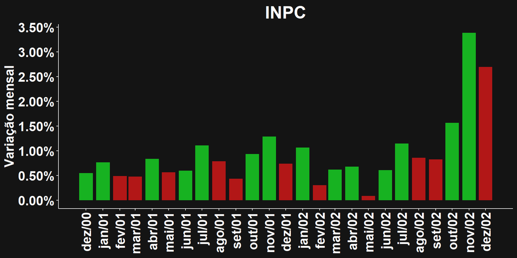

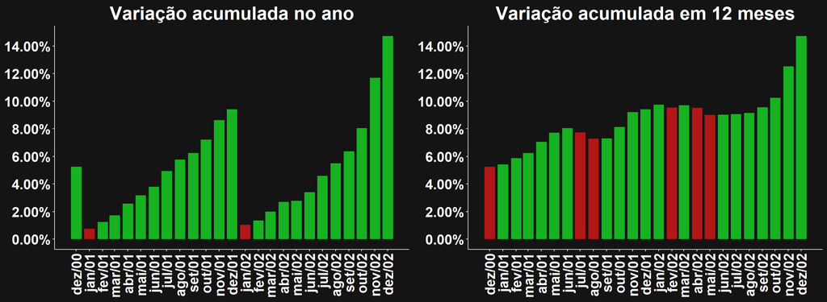

# IGP-M

O Indíce Geral de Preços de Mercado (IGP-M) variou 3.75% em dezembro, valor superior ao mesmo período do ano anterior quando apresentou uma taxa de 0.22%. Com esse resultado o indíce acumula no ano uma variação positiva de 24.86%, e em 12 meses uma variação positiva de 25.31%.

|  | 12/2001 | 11/2002 | 12/2002 |
| --- | --- | --- | --- |
| Variação mensal | 0.22% | 5.19% | 3.75% |
| Variação acumulada no ano | 9.7% | 20.34% | 24.86% |
| Variação acumulada em 12 meses | 10.38% | 21.05% | 25.31% |

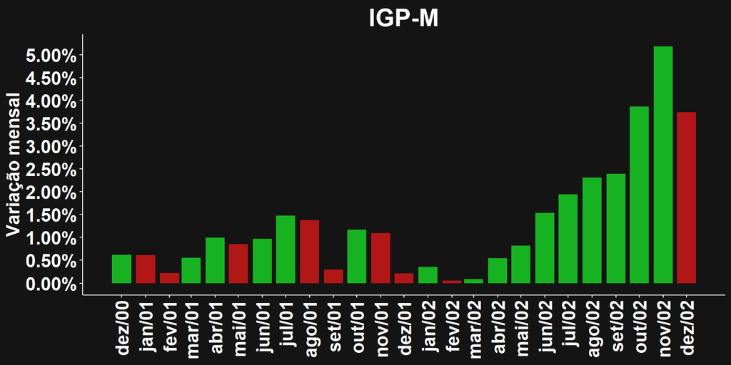

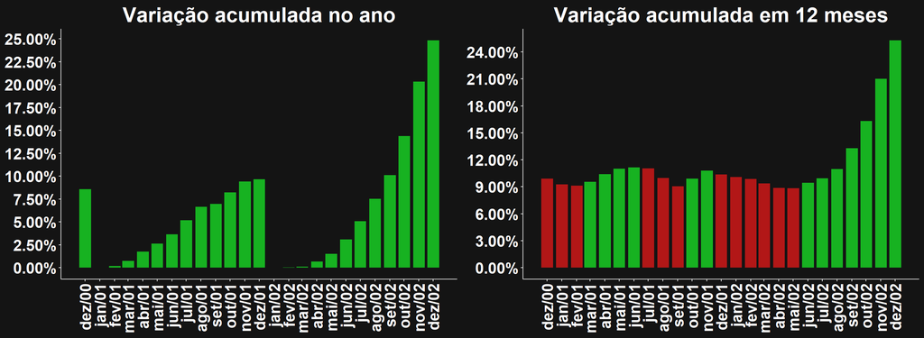

# IGP-DI

O Indíce Geral de Preços - Disponibilidade Interna (IGP-DI) variou 2.7% em dezembro, valor superior ao mesmo período do ano anterior quando apresentou uma taxa de 0.18%. Com esse resultado o indíce acumula no ano uma variação positiva de 26.18%, e em 12 meses uma variação positiva de 26.41%.

|  | 12/2001 | 11/2002 | 12/2002 |
| --- | --- | --- | --- |
| Variação mensal | 0.18% | 5.84% | 2.7% |
| Variação acumulada no ano | 9.86% | 22.86% | 26.18% |
| Variação acumulada em 12 meses | 10.4% | 23.31% | 26.41% |

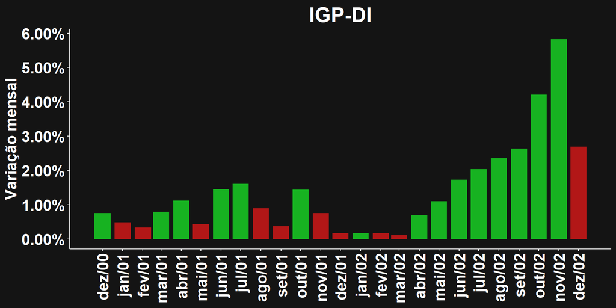

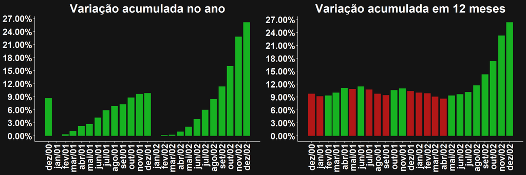

[output not shown]

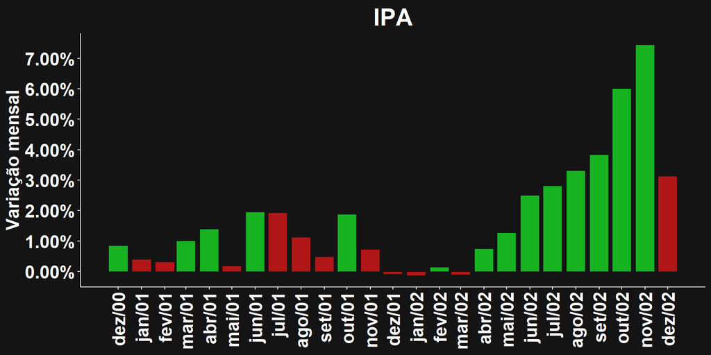

[figure not shown]

O Indíce de Preços ao Consumidor (IPC), integrante do IGP-DI com peso de 30%, apresentou variação de 1.94% em dezembro, valor superior ao mesmo período do ano anterior quando apresentou uma taxa de 0.7%. Com esse resultado o indíce acumula no ano uma variação positiva de 11.29%, e em 12 meses uma variação positiva de 12.18%.

|  | 12/2001 | 11/2002 | 12/2002 |
| --- | --- | --- | --- |
| Variação mensal | 0.7% | 3.14% | 1.94% |
| Variação acumulada no ano | 7.25% | 9.17% | 11.29% |
| Variação acumulada em 12 meses | 7.94% | 10.8% | 12.18% |

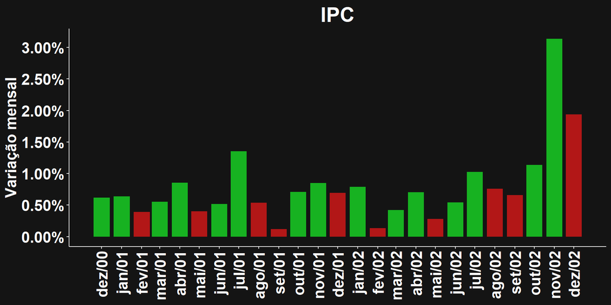

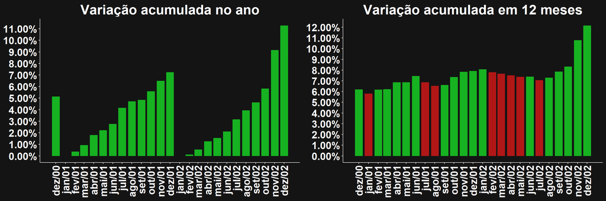

O Indíce Nacional de Custos de Construção (INCC), integrante do IGP-DI com peso de 10%, apresentou variação de 1.7% em dezembro, valor superior ao mesmo período do ano anterior quando apresentou uma taxa de 0.34%. Com esse resultado o indíce acumula no ano uma variação positiva de 12.47%, e em 12 meses uma variação positiva de 12.87%.

|  | 12/2001 | 11/2002 | 12/2002 |
| --- | --- | --- | --- |
| Variação mensal | 0.34% | 2.45% | 1.7% |
| Variação acumulada no ano | 8.23% | 10.58% | 12.47% |
| Variação acumulada em 12 meses | 8.85% | 11.36% | 12.87% |

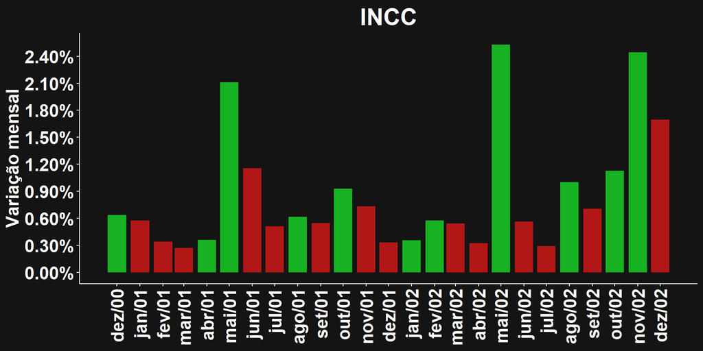

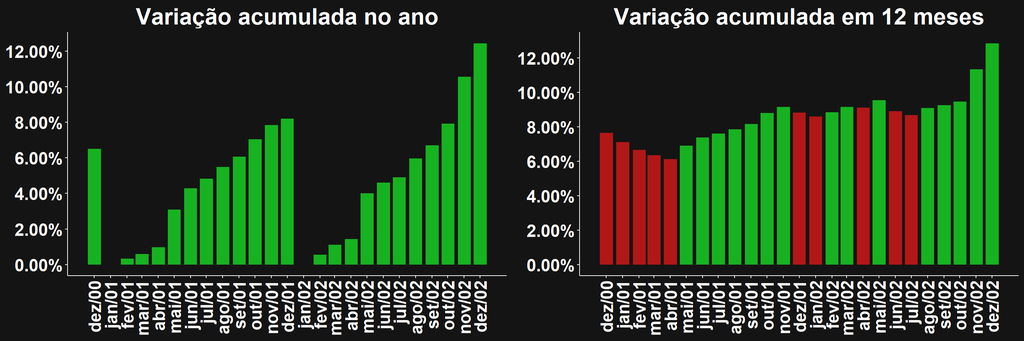

# Estatísticas

As estatísticas descritivas a seguir são feitas com base nos últimos 48 meses, e tem como objetivo possibilitar a avaliação do resultado observado em comparação aos períodos anteriores.

|  | Minimo | 1 Quartil | Mediana | Media | 3 Quartil | Maximo | Desvio Padrão |
| --- | --- | --- | --- | --- | --- | --- | --- |
| IPCA | 0.01% | 0.35% | 0.58% | 0.7% | 0.86% | 3.02% | 0.54% |
| INPC | -0.05% | 0.42% | 0.64% | 0.75% | 0.94% | 3.39% | 0.63% |
| IGP-M | -0.29% | 0.36% | 0.99% | 1.27% | 1.61% | 5.19% | 1.14% |
| IGP-DI | -0.34% | 0.39% | 1.02% | 1.28% | 1.76% | 5.84% | 1.21% |
| IPA | -0.82% | 0.4% | 1.31% | 1.66% | 2.52% | 7.45% | 1.77% |
| IPC | -0.01% | 0.4% | 0.63% | 0.71% | 0.87% | 3.14% | 0.57% |
| INCC | 0.26% | 0.41% | 0.59% | 0.77% | 0.94% | 2.53% | 0.52% |

Levando em consideração o desvio padrão de cada indíce, proporcionalmente os que mais se afastaram da média foram o INPC, o IPCA e o IGP-M.

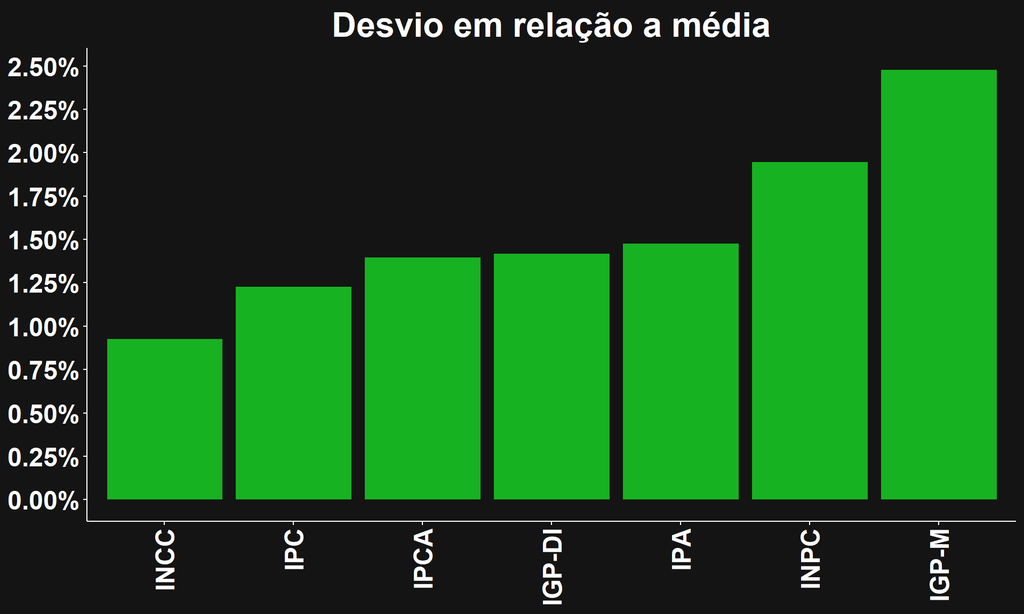

**João Victor Gomes**  
**jvg.santana@gmail.com**  
**[linkedin.com/in/jvictorgomes](https://www.linkedin.com/in/jvictorgomes/)**